# synthpop @ St. Louis R User Group

**R library synthpop.** https://cran.r-project.org/web/packages/synthpop/vignettes/synthpop.pdf

Kay Apperson, PhD.

October, 2017

**Examples of synthpop.**

SD2011: The Social Diagnosis project (Council for Social Monitoring 2011)

which aims to investigate objective and subjective quality of life in Poland.

```r
head(SD2011)
```

```
##      sex age agegr              placesize              region
## 1 FEMALE  57 45-59  URBAN 100,000-200,000            Lubuskie
## 2   MALE  20 16-24            RURAL AREAS           Podlaskie
## 3 FEMALE  18 16-24 URBAN 500,000 AND OVER         Mazowieckie
## 4 FEMALE  78   65+            RURAL AREAS           Podlaskie
## 5 FEMALE  54 45-59  URBAN 100,000-200,000 Zachodnio-pomorskie
## 6   MALE  20 16-24  URBAN 100,000-200,000             Slaskie
##                    edu                                            eduspec
## 1   VOCATIONAL/GRAMMAR services for the population and transport services
## 2   VOCATIONAL/GRAMMAR                                  no specialisation
## 3   VOCATIONAL/GRAMMAR                                  no specialisation
## 4 PRIMARY/NO EDUCATION                                  no specialisation
## 5   VOCATIONAL/GRAMMAR                     agriculture, forestry, fishing
## 6            SECONDARY                                  no specialisation
##            socprof unempdur income marital mmarr ymarr msepdiv ysepdiv
```

[output cut: 27 more lines]

Using a subset of the variables.

```r
vars <- c("sex", "age", "edu", "marital", "income", "ls", "wkabint")
ods <- SD2011[, vars]
head(ods)
```

```
##      sex age                  edu marital income               ls wkabint
## 1 FEMALE  57   VOCATIONAL/GRAMMAR MARRIED    800          PLEASED      NO
## 2   MALE  20   VOCATIONAL/GRAMMAR  SINGLE    350 MOSTLY SATISFIED      NO
## 3 FEMALE  18   VOCATIONAL/GRAMMAR  SINGLE     NA          PLEASED      NO
## 4 FEMALE  78 PRIMARY/NO EDUCATION WIDOWED    900            MIXED      NO
## 5 FEMALE  54   VOCATIONAL/GRAMMAR MARRIED   1500 MOSTLY SATISFIED      NO
## 6   MALE  20            SECONDARY  SINGLE     -8          PLEASED      NO
```

The synthesis is just one line of code `syn(ods, seed = my.seed)`.

sds is the resulting **sythesized** data set.

```r
my.seed <- 17914709
sds.default <- syn(ods, seed = my.seed)
```

```
## syn  variables
## 1    sex age edu marital income ls wkabint
```

```r
sds.default
```

```
## Call:
## ($call) syn(data = ods, seed = my.seed)
##
## Number of synthesised data sets:
## ($m)  1
##
## First rows of synthesised data set:
## ($syn)
##      sex age                  edu marital income               ls wkabint
## 1 FEMALE  67   VOCATIONAL/GRAMMAR MARRIED    520          PLEASED      NO
## 2 FEMALE  23            SECONDARY  SINGLE     NA          PLEASED      NO
## 3 FEMALE  35            SECONDARY MARRIED   1000          PLEASED      NO
## 4 FEMALE  65 PRIMARY/NO EDUCATION MARRIED   1200            MIXED      NO
## 5   MALE  67 PRIMARY/NO EDUCATION MARRIED   1500            MIXED      NO
## 6   MALE  24            SECONDARY  SINGLE   1100 MOSTLY SATISFIED      NO
## ...
##
## Synthesising methods:
## ($method)
##      sex      age      edu  marital   income       ls  wkabint
## "sample"   "cart"   "cart"   "cart"   "cart"   "cart"   "cart"
##
## Order of synthesis:
## ($visit.sequence)
##     sex     age     edu marital  income      ls wkabint
##       1       2       3       4       5       6       7
##
## Matrix of predictors:
## ($predictor.matrix)
##         sex age edu marital income ls wkabint
## sex       0   0   0       0      0  0       0
## age       1   0   0       0      0  0       0
## edu       1   1   0       0      0  0       0
## marital   1   1   1       0      0  0       0
## income    1   1   1       1      0  0       0
## ls        1   1   1       1      1  0       0
## wkabint   1   1   1       1      1  1       0
```

**sds.default$syn** is the dataframe we’re looking for.

```r
head(sds.default$syn)
```

```
##      sex age                  edu marital income               ls wkabint
## 1 FEMALE  67   VOCATIONAL/GRAMMAR MARRIED    520          PLEASED      NO
## 2 FEMALE  23            SECONDARY  SINGLE     NA          PLEASED      NO
## 3 FEMALE  35            SECONDARY MARRIED   1000          PLEASED      NO
## 4 FEMALE  65 PRIMARY/NO EDUCATION MARRIED   1200            MIXED      NO
## 5   MALE  67 PRIMARY/NO EDUCATION MARRIED   1500            MIXED      NO
## 6   MALE  24            SECONDARY  SINGLE   1100 MOSTLY SATISFIED      NO
```

```r
str(sds.default$syn)
```

```
## 'data.frame':    5000 obs. of  7 variables:
##  $ sex    : Factor w/ 2 levels "MALE","FEMALE": 2 2 2 2 1 1 2 1 2 1 ...
##  $ age    : num  67 23 35 65 67 24 29 77 53 62 ...
##  $ edu    : Factor w/ 4 levels "PRIMARY/NO EDUCATION",..: 2 3 3 1 1 3 2 3 2 2 ...
##  $ marital: Factor w/ 6 levels "SINGLE","MARRIED",..: 2 1 2 2 2 1 2 2 2 2 ...
##  $ income : num  520 NA 1000 1200 1500 1100 1300 2300 800 1500 ...
##  $ ls     : Factor w/ 7 levels "DELIGHTED","PLEASED",..: 2 2 2 4 4 3 4 3 3 2 ...
##  $ wkabint: Factor w/ 3 levels "YES, TO EU COUNTRY",..: 3 3 3 3 3 3 3 3 3 3 ...
```

```r
names(sds.default)
```

```
##  [1] "call"             "m"                "syn"
##  [4] "method"           "visit.sequence"   "predictor.matrix"
##  [7] "smoothing"        "event"            "denom"
## [10] "proper"           "n"                "k"
## [13] "rules"            "rvalues"          "cont.na"
## [16] "semicont"         "drop.not.used"    "drop.pred.only"
## [19] "models"           "seed"             "var.lab"
## [22] "val.lab"          "obs.vars"
```

```r
sdsdefault <- sds.default$syn
```

Note: We could view data in csv from RTVS or write CSV in R using `write.csv(MyData, file = "MyData.csv")`

**Force parametric.**

```r
sds.parametric <- syn(ods, method = "parametric", seed = my.seed)
```

```
## syn  variables
## 1    sex age edu marital income ls wkabint
```

```r
syn(ods,)
```

```
## syn  variables
## 1    sex age edu marital income ls wkabint
```

```
## Call:
## ($call) syn(data = ods)
##
## Number of synthesised data sets:
## ($m)  1
##
## First rows of synthesised data set:
## ($syn)
##      sex age                  edu  marital income               ls
## 1   MALE  77   VOCATIONAL/GRAMMAR DIVORCED   1400          PLEASED
## 2   MALE  62 PRIMARY/NO EDUCATION  MARRIED     NA MOSTLY SATISFIED
## 3 FEMALE  40   VOCATIONAL/GRAMMAR  MARRIED   1250 MOSTLY SATISFIED
## 4   MALE  53 PRIMARY/NO EDUCATION  MARRIED    500          PLEASED
## 5   MALE  53   VOCATIONAL/GRAMMAR  MARRIED   1500            MIXED
## 6   MALE  51            SECONDARY  MARRIED   3500          PLEASED
##              wkabint
## 1                 NO
## 2                 NO
## 3                 NO
## 4                 NO
## 5 YES, TO EU COUNTRY
## 6                 NO
## ...
##
## Synthesising methods:
## ($method)
##      sex      age      edu  marital   income       ls  wkabint
## "sample"   "cart"   "cart"   "cart"   "cart"   "cart"   "cart"
##
## Order of synthesis:
## ($visit.sequence)
##     sex     age     edu marital  income      ls wkabint
##       1       2       3       4       5       6       7
##
## Matrix of predictors:
## ($predictor.matrix)
##         sex age edu marital income ls wkabint
## sex       0   0   0       0      0  0       0
## age       1   0   0       0      0  0       0
## edu       1   1   0       0      0  0       0
## marital   1   1   1       0      0  0       0
## income    1   1   1       1      0  0       0
## ls        1   1   1       1      1  0       0
## wkabint   1   1   1       1      1  1       0
```

```r
sds.parametric$method
```

```
##        sex        age        edu    marital     income         ls
##   "sample" "normrank"  "polyreg"  "polyreg" "normrank"  "polyreg"
##    wkabint
##  "polyreg"
```

Comparing a variable

```r
compare(sds.default, ods, vars = "income")
```

```
##
## Comparing percentages observed with synthetic
##
## $income
##           -1000     0  1000 2000 3000 4000 5000 6000 7000 8000 9000 10000
## observed  12.06 24.58 34.98 9.44 2.66 1.36 0.48 0.26 0.20 0.08 0.10  0.04
## synthetic 11.20 25.60 36.30 9.32 2.68 1.26 0.52 0.18 0.22 0.14 0.04  0.02
##           11000 12000 13000 14000 15000 miss.NA
## observed   0.02     0     0  0.06  0.02   13.66
## synthetic  0.00     0     0  0.04  0.00   12.48
```

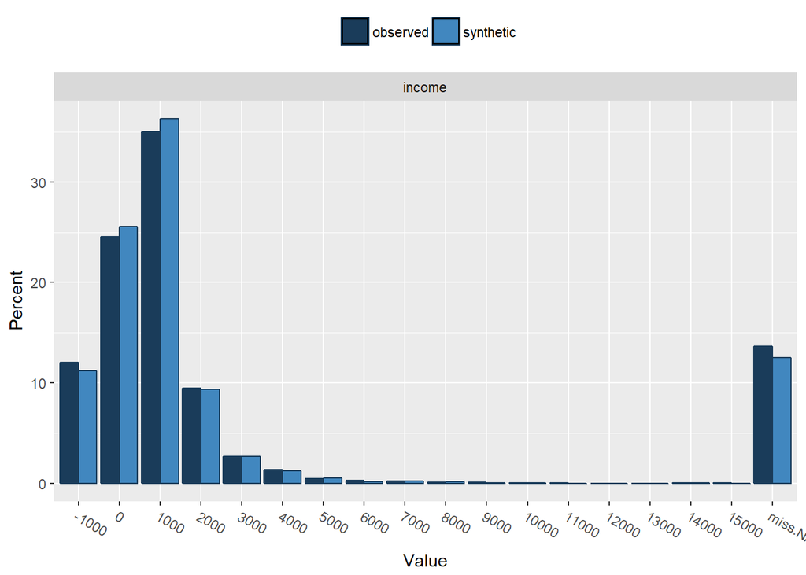

```r
compare(sds.parametric, ods, vars = "income")
```

```
##
## Comparing percentages observed with synthetic
##
## $income
##           -1000     0  1000 2000 3000 4000 5000 6000 7000 8000 9000 10000
## observed  12.06 24.58 34.98 9.44 2.66 1.36 0.48 0.26 0.20 0.08  0.1  0.04
## synthetic 10.82 25.04 35.94 9.40 2.52 1.32 0.34 0.30 0.04 0.08  0.1  0.06
##           11000 12000 13000 14000 15000 miss.NA
## observed   0.02     0     0  0.06  0.02   13.66
## synthetic  0.02     0     0  0.08  0.00   13.94
```

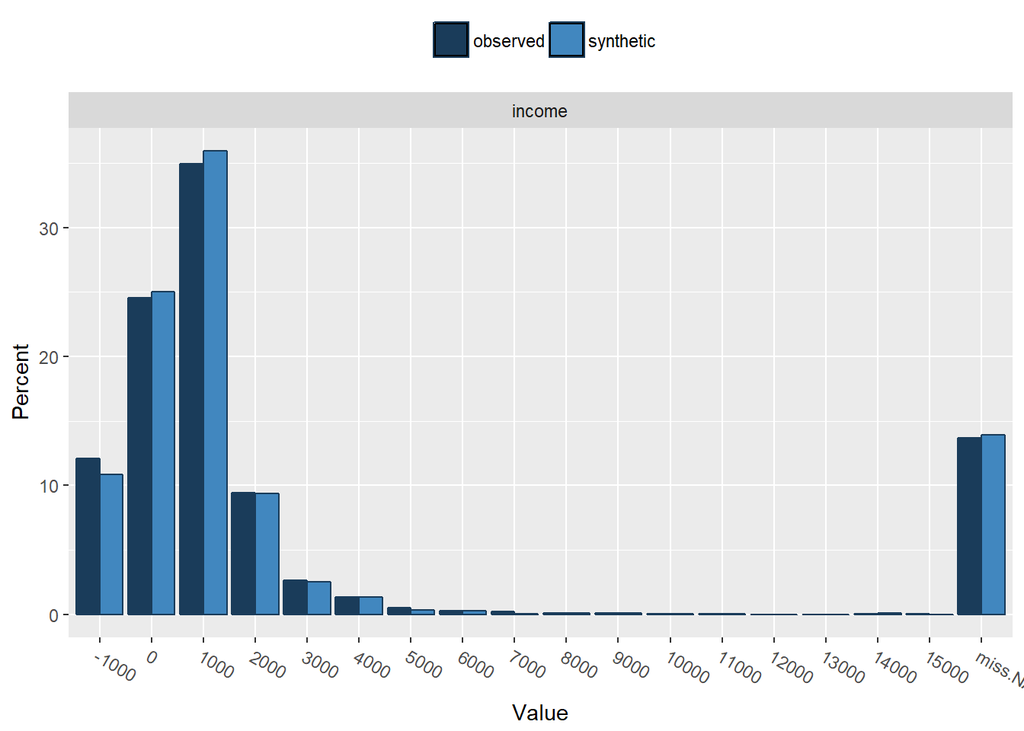

**Extended examples.**

*Ex1.* Change the sequence of variables, and also skip a few of them.

```r
sds.selection <- syn(ods, visit.sequence = c(1, 2, 6, 4, 3), seed = my.seed, drop.not.used = TRUE)
```

```
##
## Variable(s): income, wkabint not synthesised or used in prediction.
## The variable(s) will be removed from data and not saved in synthesised data.
##
## syn  variables
## 1    sex age ls marital edu
```

```r
sds.selection
```

```
## Call:
## ($call) syn(data = ods, visit.sequence = c(1, 2, 6, 4, 3), drop.not.used = TRUE,
##     seed = my.seed)
##
## Number of synthesised data sets:
## ($m)  1
##
## First rows of synthesised data set:
## ($syn)
##      sex age                      edu marital               ls
## 1 FEMALE  67     PRIMARY/NO EDUCATION MARRIED            MIXED
## 2 FEMALE  23 POST-SECONDARY OR HIGHER  SINGLE          PLEASED
## 3 FEMALE  35                SECONDARY MARRIED MOSTLY SATISFIED
## 4 FEMALE  65                SECONDARY MARRIED MOSTLY SATISFIED
## 5   MALE  67 POST-SECONDARY OR HIGHER  SINGLE MOSTLY SATISFIED
## 6   MALE  24                SECONDARY  SINGLE MOSTLY SATISFIED
## ...
##
## Synthesising methods:
## ($method)
##      sex      age      edu  marital       ls
## "sample"   "cart"   "cart"   "cart"   "cart"
##
## Order of synthesis:
## ($visit.sequence)
##     sex     age      ls marital     edu
##       1       2       5       4       3
##
## Matrix of predictors:
## ($predictor.matrix)
##         sex age edu marital ls
## sex       0   0   0       0  0
## age       1   0   0       0  0
## edu       1   1   0       1  1
## marital   1   1   0       0  1
## ls        1   1   0       0  0
```

*Ex2.* Build parameter.matrix.corrected without synthesizing first.

Then use parameter.matrix.correct in another synthesis.

1. Build.

```r
visit.sequence.ini <- c(1, 2, 5, 6, 4, 3)
method.ini <- c("sample", "ctree", "ctree", "polyreg", "", "ctree", "")
sds.ini <- syn(data = ods, visit.sequence = visit.sequence.ini, method = method.ini, m = 0, drop.not.used = FALSE)
```

```
##
## Variable(s): wkabint not synthesised or used in prediction.
## CAUTION: The synthesised data will contain the variable(s) unchanged.
```

```r
sds.ini$predictor.matrix
```

```
##         sex age edu marital income ls wkabint
## sex       0   0   0       0      0  0       0
## age       1   0   0       0      0  0       0
## edu       1   1   0       1      1  1       0
## marital   1   1   0       0      1  1       0
## income    0   0   0       0      0  0       0
## ls        1   1   0       0      1  0       0
## wkabint   0   0   0       0      0  0       0
```

```r
predictor.matrix.corrected <- sds.ini$predictor.matrix
predictor.matrix.corrected["marital", "ls"] <- 0
predictor.matrix.corrected
```

```
##         sex age edu marital income ls wkabint
## sex       0   0   0       0      0  0       0
## age       1   0   0       0      0  0       0
## edu       1   1   0       1      1  1       0
## marital   1   1   0       0      1  0       0
## income    0   0   0       0      0  0       0
## ls        1   1   0       0      1  0       0
## wkabint   0   0   0       0      0  0       0
```

2. Use.

```r
sds.corrected <- syn(data = ods, visit.sequence = visit.sequence.ini,
                 method = method.ini, predictor.matrix = predictor.matrix.corrected,
                 seed = my.seed)
```

```
##
## Variable(s): wkabint not synthesised or used in prediction.
## CAUTION: The synthesised data will contain the variable(s) unchanged.
##
## syn  variables
## 1    sex age income ls marital edu
```

*Ex 3.* Define numeric missing data encodings, e.g. -9999, etc. In this case, it’s -8.

In this case, income can be NA or -8 when missing.

```r
sds.income <- syn(ods, cont.na = list(income = c(NA, -8)), smoothing = list(income = "density"), seed = NA)
```

```
## syn  variables
## 1    sex age edu marital income ls wkabint
```

```r
sds.income
```

```
## Call:
## ($call) syn(data = ods, cont.na = list(income = c(NA, -8)), smoothing = list(income = "density"),
##     seed = NA)
##
## Number of synthesised data sets:
## ($m)  1
##
## First rows of synthesised data set:
## ($syn)
##      sex age                      edu marital income               ls
## 1   MALE  60       VOCATIONAL/GRAMMAR MARRIED    747 MOSTLY SATISFIED
## 2   MALE  22 POST-SECONDARY OR HIGHER  SINGLE     -8 MOSTLY SATISFIED
## 3 FEMALE  72     PRIMARY/NO EDUCATION MARRIED    843            MIXED
## 4 FEMALE  55 POST-SECONDARY OR HIGHER MARRIED     NA            MIXED
## 5   MALE  20       VOCATIONAL/GRAMMAR  SINGLE     -8 MOSTLY SATISFIED
## 6 FEMALE  78                SECONDARY MARRIED    902          PLEASED
##   wkabint
## 1      NO
## 2      NO
## 3      NO
## 4      NO
## 5      NO
## 6      NO
## ...
##
## Synthesising methods:
## ($method)
##      sex      age      edu  marital   income       ls  wkabint
## "sample"   "cart"   "cart"   "cart"   "cart"   "cart"   "cart"
##
## Order of synthesis:
## ($visit.sequence)
##     sex     age     edu marital  income      ls wkabint
##       1       2       3       4       5       6       7
##
## Matrix of predictors:
## ($predictor.matrix)
##         sex age edu marital income ls wkabint
## sex       0   0   0       0      0  0       0
## age       1   0   0       0      0  0       0
## edu       1   1   0       0      0  0       0
## marital   1   1   1       0      0  0       0
## income    1   1   1       1      0  0       0
## ls        1   1   1       1      1  0       0
## wkabint   1   1   1       1      1  1       0
```

*Ex 4.* Restricted values according to business logic.

Males must be 18 or older to be legally married.

Build rules.marital and use it in the parameter “rules” in syn().

1. Build.

```r
M18.ods <- table(subset(ods, age < 18 & sex == "MALE", marital))
M18.default <- table(subset(sds.default$syn, age < 18 & sex == "MALE", marital))
M18.parametric <- table(subset(sds.parametric$syn, age < 18 & sex == "MALE", marital))
cbind("Observed data" = M18.ods, CART = M18.default, Parametric = M18.parametric)
```

```
##                    Observed data CART Parametric
## SINGLE                        57   56         49
## MARRIED                        0    2          3
## WIDOWED                        0    0          0
## DIVORCED                       0    0          0
## LEGALLY SEPARATED              0    0          0
## DE FACTO SEPARATED             0    0          0
```

```r
rules.marital <- list(marital = "age < 18 & sex == 'MALE'")
rvalues.marital <- list(marital = "SINGLE")
```

2. Use two ways, default and parametric.

[output not shown]

[output not shown]

3. A summary table can be produced as follows.

```r
rM18.default <- table(subset(sds.rmarital$syn, age < 18 & sex == "MALE", marital))
rM18.parametric <- table(subset(sds.rmarital.param$syn, age < 18 & sex == "MALE", marital))
cbind("Observed data" = M18.ods, CART = rM18.default, Parametric = rM18.parametric)
```

```
##                    Observed data CART Parametric
## SINGLE                        57   58         52
## MARRIED                        0    0          0
## WIDOWED                        0    0          0
## DIVORCED                       0    0          0
## LEGALLY SEPARATED              0    0          0
## DE FACTO SEPARATED             0    0          0
```

**Synthetic data analysis**

```r
ods$wkabint <- as.character(ods$wkabint)
ods$wkabint[ods$wkabint == "YES, TO EU COUNTRY" | ods$wkabint == "YES, TO NON-EU COUNTRY"] <- "YES"
ods$wkabint <- factor(ods$wkabint)
ods$income[ods$income == -8] <- NA
```

Synthesize 5 datasets/syntheses using m = 5.

```r
sds <- syn(ods, method = "ctree", m = 5, seed = my.seed)
```

```
## syn  variables
## 1    sex age edu marital income ls wkabint
## 2    sex age edu marital income ls wkabint
## 3    sex age edu marital income ls wkabint
## 4    sex age edu marital income ls wkabint
## 5    sex age edu marital income ls wkabint
```

```r
summary(ods)
```

```
##      sex            age                              edu
##  MALE  :2182   Min.   :16.00   PRIMARY/NO EDUCATION    : 962
##  FEMALE:2818   1st Qu.:32.00   VOCATIONAL/GRAMMAR      :1613
##                Median :49.00   SECONDARY               :1482
##                Mean   :47.68   POST-SECONDARY OR HIGHER: 936
##                3rd Qu.:61.00   NA's                    :   7
##                Max.   :97.00
##
##                marital         income                          ls
##  SINGLE            :1253   Min.   :  100.0   PLEASED            :1947
##  MARRIED           :2979   1st Qu.:  970.5   MOSTLY SATISFIED   :1692
##  WIDOWED           : 531   Median : 1350.0   MIXED              : 827
##  DIVORCED          : 199   Mean   : 1641.5   MOSTLY DISSATISFIED: 274
##  LEGALLY SEPARATED :   7   3rd Qu.: 2000.0   DELIGHTED          : 191
##  DE FACTO SEPARATED:  22   Max.   :16000.0   (Other)            :  61
##  NA's              :   9   NA's   :1286      NA's               :   8
##  wkabint
##  NO  :4646
##  YES : 318
##  NA's:  36
##
##
##
##
```

```r
summary(sds)
```

```
## Synthetic object with 5 syntheses using methods:
##      sex      age      edu  marital   income       ls  wkabint
## "sample"  "ctree"  "ctree"  "ctree"  "ctree"  "ctree"  "ctree"
##
## Summary (average) for all synthetic data sets:
##      sex            age                              edu
##  MALE  :2169   Min.   :16.00   PRIMARY/NO EDUCATION    : 964.0
##  FEMALE:2831   1st Qu.:32.00   VOCATIONAL/GRAMMAR      :1593.6
##                Median :48.60   SECONDARY               :1501.4
##                Mean   :47.76   POST-SECONDARY OR HIGHER: 935.8
##                3rd Qu.:61.60   NA's                    :   5.2
##                Max.   :95.60
##
##                marital           income
##  SINGLE            :1246.0   Min.   :  100.0
##  MARRIED           :2986.2   1st Qu.:  955.2
##  WIDOWED           : 543.6   Median : 1310.0
##  DIVORCED          : 187.2   Mean   : 1632.0
##  LEGALLY SEPARATED :   6.8   3rd Qu.: 2000.0
##  DE FACTO SEPARATED:  21.2   Max.   :15600.0
##  NA's              :   9.0   NA's   : 1260.0
##                    ls         wkabint
##  PLEASED            :1964.4   NO  :4634.8
##  MOSTLY SATISFIED   :1672.6   YES : 330.4
##  MIXED              : 836.8   NA's:  34.8
##  MOSTLY DISSATISFIED: 281.6
##  DELIGHTED          : 179.4
##  (Other)            :  56.4
##  NA's               :   8.8
```

Use msel to show one or more syntheses.

```r
summary(sds, msel = 2)
```

```
## Synthetic object with 5 syntheses using methods:
##      sex      age      edu  marital   income       ls  wkabint
## "sample"  "ctree"  "ctree"  "ctree"  "ctree"  "ctree"  "ctree"
##
## Summary for synthetic data set 2:
##      sex            age                              edu
##  MALE  :2110   Min.   :16.00   PRIMARY/NO EDUCATION    : 979
##  FEMALE:2890   1st Qu.:32.00   VOCATIONAL/GRAMMAR      :1589
##                Median :49.00   SECONDARY               :1498
##                Mean   :48.03   POST-SECONDARY OR HIGHER: 931
##                3rd Qu.:62.00   NA's                    :   3
##                Max.   :96.00
##
##                marital         income                        ls
##  SINGLE            :1183   Min.   :  100   PLEASED            :1967
##  MARRIED           :3030   1st Qu.:  930   MOSTLY SATISFIED   :1672
##  WIDOWED           : 558   Median : 1300   MIXED              : 834
##  DIVORCED          : 194   Mean   : 1622   MOSTLY DISSATISFIED: 286
##  LEGALLY SEPARATED :   5   3rd Qu.: 2000   DELIGHTED          : 181
##  DE FACTO SEPARATED:  21   Max.   :16000   (Other)            :  43
##  NA's              :   9   NA's   :1253    NA's               :  17
##  wkabint
##  NO  :4656
##  YES : 306
##  NA's:  38
##
##
##
##
```

```r
summary(sds, msel = 1:5)
```

```
## Synthetic object with 5 syntheses using methods:
##      sex      age      edu  marital   income       ls  wkabint
## "sample"  "ctree"  "ctree"  "ctree"  "ctree"  "ctree"  "ctree"
##
## Summary for synthetic data set 1:
##      sex            age                              edu
##  MALE  :2180   Min.   :16.00   PRIMARY/NO EDUCATION    : 959
##  FEMALE:2820   1st Qu.:32.00   VOCATIONAL/GRAMMAR      :1611
##                Median :49.00   SECONDARY               :1486
##                Mean   :47.74   POST-SECONDARY OR HIGHER: 936
##                3rd Qu.:62.00   NA's                    :   8
##                Max.   :97.00
##
##                marital         income                        ls
##  SINGLE            :1279   Min.   :  100   PLEASED            :1939
##  MARRIED           :2985   1st Qu.:  968   MOSTLY SATISFIED   :1672
##  WIDOWED           : 521   Median : 1350   MIXED              : 861
##  DIVORCED          : 176   Mean   : 1613   MOSTLY DISSATISFIED: 288
##  LEGALLY SEPARATED :   6   3rd Qu.: 2000   DELIGHTED          : 177
##  DE FACTO SEPARATED:  24   Max.   :16000   (Other)            :  55
##  NA's              :   9   NA's   :1246    NA's               :   8
##  wkabint
##  NO  :4637
##  YES : 335
##  NA's:  28
##
##
##
##
##
## Summary for synthetic data set 2:
##      sex            age                              edu
##  MALE  :2110   Min.   :16.00   PRIMARY/NO EDUCATION    : 979
##  FEMALE:2890   1st Qu.:32.00   VOCATIONAL/GRAMMAR      :1589
##                Median :49.00   SECONDARY               :1498
##                Mean   :48.03   POST-SECONDARY OR HIGHER: 931
##                3rd Qu.:62.00   NA's                    :   3
##                Max.   :96.00
##
##                marital         income                        ls
```

[output cut: 78 more lines]

```
##  SINGLE            :1271   Min.   :  100   PLEASED            :1960
##  MARRIED           :2936   1st Qu.:  978   MOSTLY SATISFIED   :1656
##  WIDOWED           : 558   Median : 1300   MIXED              : 836
##  DIVORCED          : 198   Mean   : 1627   MOSTLY DISSATISFIED: 288
##  LEGALLY SEPARATED :   7   3rd Qu.: 2000   DELIGHTED          : 185
##  DE FACTO SEPARATED:  24   Max.   :15000   (Other)            :  66
##  NA's              :   6   NA's   :1300    NA's               :   9
##  wkabint
##  NO  :4621
##  YES : 345
##  NA's:  34
##
##
##
##
```

```r
compare(sds, ods, vars = "income")
```

```
##
## Comparing percentages observed with synthetic
##
## $income
##                0   1000  2000 3000  4000  5000  6000 7000  8000 9000 10000
## observed  24.580 34.980 9.440 2.66 1.360 0.480 0.260 0.20 0.080 0.10 0.040
## synthetic 25.328 34.664 9.472 2.66 1.448 0.484 0.336 0.16 0.044 0.06 0.036
##           11000 12000 13000 14000 15000 miss.NA
## observed   0.02     0     0 0.060 0.020   25.72
## synthetic  0.02     0     0 0.076 0.012   25.20
```

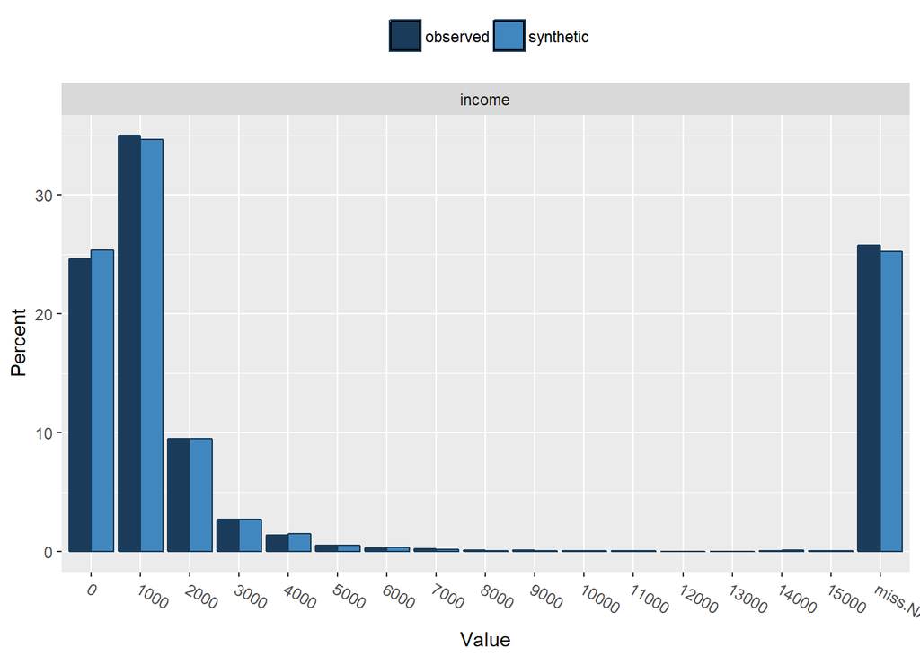

```r
compare(sds, ods, vars = "ls", msel = 1:3)
```

```
##
## Comparing percentages observed with synthetic
##
## $ls
##          DELIGHTED PLEASED MOSTLY SATISFIED MIXED MOSTLY DISSATISFIED
## observed      3.82   38.94            33.84 16.54                5.48
## syn=1         3.54   38.78            33.44 17.22                5.76
## syn=2         3.62   39.34            33.44 16.68                5.72
## syn=3         3.66   38.92            34.34 16.66                5.14
##          UNHAPPY TERRIBLE <NA>
## observed    0.82     0.40 0.16
## syn=1       0.66     0.44 0.16
## syn=2       0.66     0.20 0.34
## syn=3       0.74     0.44 0.10
```

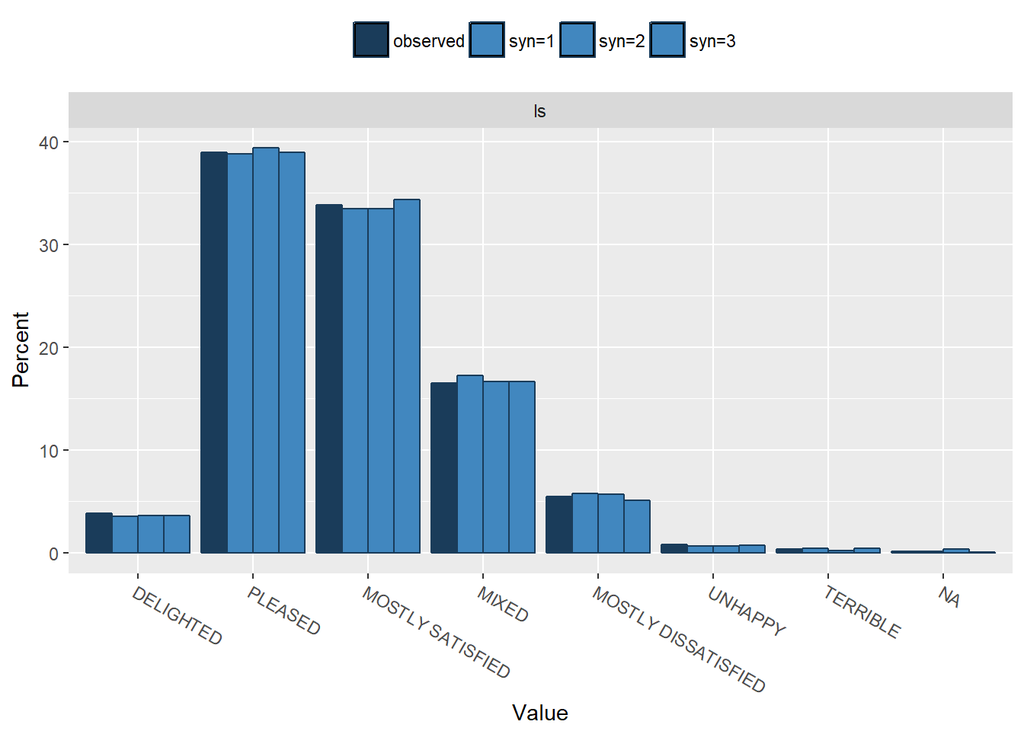

**Build models on original data and syntheses.**

There are glm.synds() and lm.synds() functions to use for syntheses. 1. The glm model for ods.

```r
model.ods <- glm(wkabint ~ sex + age + edu + log(income), family = "binomial", data = ods)
model.ods
```

```
##
## Call:  glm(formula = wkabint ~ sex + age + edu + log(income), family = "binomial",
##     data = ods)
##
## Coefficients:
##                 (Intercept)                    sexFEMALE
##                    -0.21052                     -0.47387
##                         age        eduVOCATIONAL/GRAMMAR
##                    -0.05384                      0.62753
##                eduSECONDARY  eduPOST-SECONDARY OR HIGHER
##                     0.36839                     -0.18697
##                 log(income)
##                    -0.04610
##
## Degrees of Freedom: 3690 Total (i.e. Null);  3684 Residual
##   (1309 observations deleted due to missingness)
## Null Deviance:       1544
## Residual Deviance: 1372  AIC: 1386
```

```r
summary(model.ods)
```

```
##
## Call:
## glm(formula = wkabint ~ sex + age + edu + log(income), family = "binomial",
##     data = ods)
##
## Deviance Residuals:
##     Min       1Q   Median       3Q      Max
## -0.8727  -0.3687  -0.2505  -0.1625   3.0776
##
## Coefficients:
##                              Estimate Std. Error z value Pr(>|z|)
## (Intercept)                 -0.210518   0.891248  -0.236  0.81327
## sexFEMALE                   -0.473873   0.161820  -2.928  0.00341 **
## age                         -0.053835   0.005559  -9.684  < 2e-16 ***
## eduVOCATIONAL/GRAMMAR        0.627528   0.307576   2.040  0.04133 *
## eduSECONDARY                 0.368386   0.321252   1.147  0.25150
## eduPOST-SECONDARY OR HIGHER -0.186965   0.366956  -0.510  0.61040
## log(income)                 -0.046104   0.122240  -0.377  0.70605
## ---
## Signif. codes:  0 '***' 0.001 '**' 0.01 '*' 0.05 '.' 0.1 ' ' 1
##
## (Dispersion parameter for binomial family taken to be 1)
##
##     Null deviance: 1543.6  on 3690  degrees of freedom
## Residual deviance: 1371.7  on 3684  degrees of freedom
##   (1309 observations deleted due to missingness)
## AIC: 1385.7
##
## Number of Fisher Scoring iterations: 7
```

2. The glm for sds.

```r
model.sds <- glm.synds(wkabint ~ sex + age + edu + log(income),
             family = "binomial", data = sds)
model.sds
```

```
##
## Call:
## glm.synds(formula = wkabint ~ sex + age + edu + log(income),
##     family = "binomial", data = sds)
##
## Combined coefficient estimates:
##                 (Intercept)                   sexFEMALE
##                -0.505470162                -0.521555336
##                         age       eduVOCATIONAL/GRAMMAR
##                -0.046265964                 0.140273368
##                eduSECONDARY eduPOST-SECONDARY OR HIGHER
##                 0.066206331                -0.173502647
##                 log(income)
##                -0.004930097
```

```r
summary(model.sds)
```

```
##
## Fit to synthetic data set with 5 syntheses.
## Inference to coefficients and standard errors
## that would be obtained from the observed data.
##
## Call:
## glm.synds(formula = wkabint ~ sex + age + edu + log(income),
##     family = "binomial", data = sds)
##
## Combined estimates:
##                                    B.syn se(Beta).syn       Z.syn
## (Intercept)                 -0.505470162  0.984395650 -0.51348273
## sexFEMALE                   -0.521555336  0.158069024 -3.29954170
## age                         -0.046265964  0.005240696 -8.82820923
## eduVOCATIONAL/GRAMMAR        0.140273368  0.267637189  0.52411762
## eduSECONDARY                 0.066206331  0.275793418  0.24005769
## eduPOST-SECONDARY OR HIGHER -0.173502647  0.312116234 -0.55589113
## log(income)                 -0.004930097  0.130486126 -0.03778254
```

```r
# next to each other.
summary(model.ods)
```

```
##
## Call:
## glm(formula = wkabint ~ sex + age + edu + log(income), family = "binomial",
##     data = ods)
##
## Deviance Residuals:
##     Min       1Q   Median       3Q      Max
## -0.8727  -0.3687  -0.2505  -0.1625   3.0776
##
## Coefficients:
##                              Estimate Std. Error z value Pr(>|z|)
## (Intercept)                 -0.210518   0.891248  -0.236  0.81327
## sexFEMALE                   -0.473873   0.161820  -2.928  0.00341 **
## age                         -0.053835   0.005559  -9.684  < 2e-16 ***
## eduVOCATIONAL/GRAMMAR        0.627528   0.307576   2.040  0.04133 *
## eduSECONDARY                 0.368386   0.321252   1.147  0.25150
## eduPOST-SECONDARY OR HIGHER -0.186965   0.366956  -0.510  0.61040
## log(income)                 -0.046104   0.122240  -0.377  0.70605
## ---
## Signif. codes:  0 '***' 0.001 '**' 0.01 '*' 0.05 '.' 0.1 ' ' 1
##
## (Dispersion parameter for binomial family taken to be 1)
##
##     Null deviance: 1543.6  on 3690  degrees of freedom
## Residual deviance: 1371.7  on 3684  degrees of freedom
##   (1309 observations deleted due to missingness)
## AIC: 1385.7
##
## Number of Fisher Scoring iterations: 7
```

```r
summary(model.sds)
```

```
##
## Fit to synthetic data set with 5 syntheses.
## Inference to coefficients and standard errors
## that would be obtained from the observed data.
##
## Call:
## glm.synds(formula = wkabint ~ sex + age + edu + log(income),
##     family = "binomial", data = sds)
##
## Combined estimates:
##                                    B.syn se(Beta).syn       Z.syn
## (Intercept)                 -0.505470162  0.984395650 -0.51348273
## sexFEMALE                   -0.521555336  0.158069024 -3.29954170
## age                         -0.046265964  0.005240696 -8.82820923
## eduVOCATIONAL/GRAMMAR        0.140273368  0.267637189  0.52411762
## eduSECONDARY                 0.066206331  0.275793418  0.24005769
## eduPOST-SECONDARY OR HIGHER -0.173502647  0.312116234 -0.55589113
## log(income)                 -0.004930097  0.130486126 -0.03778254
```